# Red state, blue state: The polarizing influence of color in political maps. *Data Cleaning and Analyses*

Rémy A. Furrer, Adrienne Wood, Gary Lupyan, Karen Schloss, & Paula M. Niedenthal

11/3/2020

# Read in data and remove bots, inattentive participants, and unfinished surveys

```r
df <-read.csv("Maps Political Polarization Experiment_November 3, 2020_10.01.csv")
DT::datatable(df[1:10,],caption="Sample Raw Data")
```

|  | StartDate | EndDate | Status | Progress | Duration..in.seconds. | Finished | RecordedDate | ResponseId | RecipientLastName | RecipientFirstName | RecipientEmail | ExternalReference | DistributionChannel | UserLanguage | Q281_Browser | Q281_Version | Q281_Operating.System | Q281_Resolution | Q283_Browser | Q283_Version | Q283_Operating.System | Q283_Resolution | Q205 | Q284_1 | Q284_2 | Q284_3 | Q290_1 | Q290_2 | Q290_3 | … |
| --- | --- | --- | --- | --- | --- | --- | --- | --- | --- | --- | --- | --- | --- | --- | --- | --- | --- | --- | --- | --- | --- | --- | --- | --- | --- | --- | --- | --- | --- | --- |
| 1 | 10/30/20 5:22 | 10/30/20 5:23 | 0 | 100 | 49 | 1 | 10/30/20 5:23 | R_3mf1DO9U012rFHX |  |  |  |  | anonymous | EN |  |  |  |  |  |  |  |  | 1 |  |  |  | Like | Dislike | Dislike | … |
| 2 | 10/30/20 5:18 | 10/30/20 5:24 | 0 | 100 | 312 | 1 | 10/30/20 5:24 | R_4N7qUlmYuAbWGAN |  |  |  |  | anonymous | EN |  |  |  |  |  |  |  |  | 1 |  |  |  | Dislike | Neutral | Like | … |
| 3 | 10/30/20 5:23 | 10/30/20 5:24 | 0 | 100 | 74 | 1 | 10/30/20 5:24 | R_6Go46BAs3xersKR |  |  |  |  | anonymous | EN |  |  |  |  |  |  |  |  | 1 |  |  |  |  |  |  | … |
| 4 | 10/30/20 5:21 | 10/30/20 5:28 | 0 | 100 | 414 | 1 | 10/30/20 5:28 | R_2169fZ3QjRCtBpm |  |  |  |  | anonymous | EN |  |  |  |  |  |  |  |  | 1 |  |  |  |  |  |  | … |
| 5 | 10/30/20 5:22 | 10/30/20 5:31 | 0 | 100 | 503 | 1 | 10/30/20 5:31 | R_1hVViTMqxFbiZEO |  |  |  |  | anonymous | EN |  |  |  |  |  |  |  |  | 1 |  |  |  |  |  |  | … |
| 6 | 10/30/20 5:27 | 10/30/20 5:35 | 0 | 100 | 463 | 1 | 10/30/20 5:35 | R_1LHvf4XVSs7bP1h |  |  |  |  | anonymous | EN |  |  |  |  |  |  |  |  | 1 |  |  |  |  |  |  | … |
| 7 | 10/30/20 5:28 | 10/30/20 5:36 | 0 | 100 | 515 | 1 | 10/30/20 5:36 | R_d1o2M4s5Gn2YLOV |  |  |  |  | anonymous | EN |  |  |  |  |  |  |  |  | 1 |  |  |  |  |  |  | … |
| 8 | 10/30/20 5:25 | 10/30/20 5:37 | 0 | 100 | 693 | 1 | 10/30/20 5:37 | R_3QYuwPL1tFpP4yh |  |  |  |  | anonymous | EN |  |  |  |  |  |  |  |  | 1 |  |  |  | Dislike | Neutral | Like | … |
| 9 | 10/30/20 5:29 | 10/30/20 5:40 | 0 | 100 | 636 | 1 | 10/30/20 5:40 | R_20Maf9iiKY70A7h |  |  |  |  | anonymous | EN |  |  |  |  |  |  |  |  | 1 |  |  |  |  |  |  | … |
| 10 | 10/30/20 5:34 | 10/30/20 5:40 | 0 | 100 | 360 | 1 | 10/30/20 5:40 | R_RJkhW7jnLQlbUfT |  |  |  |  | anonymous | EN |  |  |  |  |  |  |  |  | 1 |  |  |  |  |  |  | … |

```r
set.seed(14)
```

## Remove bad data, as preregistered

We’ll delete participants who: 1. Failed the initial bot check 2. Failed the mid-way attention check 3. Did not say what the study was about using any of the following stems: map*, politic*, color*, vot*, democrat*, republican*, u.s*, us*, or united states* 4. Said they used outside sources in the debriefing questions at the end 5. Gave the same responses on 4/8 trials of the Polarization Task (Task 1) **Note: we preregistered that we would delete participants who left the survey browser during the task but failed to record that information, so we have to deviate from the preregistration in that way. We also failed to ask participants if they had color vision deficit so we will deviate from the preregistration in that way as well.**

```r
## 1. bot check
# x, check, 0 version
df$botPass <-ifelse(df$Q284_1=="Dislike"&df$Q284_2=="Like"&df$Q284_3=="Neutral",1,0)
# x, 0, check version
df$botPass <-ifelse(df$Q290_1=="Dislike"&df$Q290_2=="Neutral"&df$Q290_3=="Like",1,df$botPass)
#  check, x, 0 version
df$botPass <-ifelse(df$Q287_1=="Like"&df$Q287_2=="Dislike"&df$Q287_3=="Neutral",1,df$botPass)
#  check, 0, x version
df$botPass <-ifelse(df$Q293_1=="Like"&df$Q293_2=="Neutral"&df$Q293_3=="Dislike",1,df$botPass)
#  check, x, 0 version
df$botPass <-ifelse(df$Q287_1=="Like"&df$Q287_2=="Dislike"&df$Q287_3=="Neutral",1,df$botPass)
#  check, x, 0 version
df$botPass <-ifelse(df$Q296_1=="Neutral"&df$Q296_2=="Like"&df$Q296_3=="Dislike",1,df$botPass)
#  check, x, 0 version
df$botPass <-ifelse(df$Q299_1=="Neutral"&df$Q299_2=="Dislike"&df$Q299_3=="Like",1,df$botPass)

botStatement <-paste("This many respondents failed the initial bot check: ",as.character(nrow(df[df$botPass==0,]))," and this many passed: ",as.character(nrow(df[df$botPass==1,])), sep="")

df <- df[df$botPass==1,]

# 2. failed mid-way attention check (California map click)
df$attentionPass <-ifelse(df$Q228_1=="Like",1,0)
attentionStatement <-paste("This many respondents failed the Cali attention check: ",as.character(nrow(df[df$attentionPass==0,]))," and this many passed: ",as.character(nrow(df[df$attentionPass==1,])), sep="")
df <- df[df$attentionPass==1,]

# 3. Did not say study was about map\*, politic\*, color\*, vot\*, democrat\*, republican\*, u.s\*, us\*, or united states\*
df$manipulationPass <-NA
for(i in 1:nrow(df)){
  df[i,"manipulationPass"]<-(str_contains(df[i,"Q236"],c("map", "politic", "color", "vot", "democrat", "republican", "u.s", "us", "united states"),ignore.case=TRUE, logic="or"))}
df$manipulationPass <-ifelse(df$manipulationPass==TRUE,1,0)


manipulationStatement <-paste("This many respondents failed the manipulation attention check: ",as.character(nrow(df[df$manipulationPass==0,]))," and this many passed: ",as.character(nrow(df[df$manipulationPass==1,])), sep="")

# 4. Used outside resources
outsideResourcesStatement <-paste("This many respondents said they used outside resources: ",as.character(nrow(df[df$Q262==1,]))," and this many did not: ",as.character(nrow(df[df$Q262==2,])), sep="")

df$outsideResources <-ifelse(df$Q262==2,"no","yes")
```

## Prepare data for analyses

Convert from wide to long and separate the Task 1 and Task 2 data

```r
# list of demographics variables and responses to open-ended questions at end
demographicsVars <-c("subjectID",
                    "Party_Likeability_Democrats",
                     "Party_Likeability_Republicans",
                     "Polarization_More_Divided_Than_Before",
                     "Polarization_Problem",
                     "Polarization_Half_Country_Ignored",
                     "Polarization_Same_Values",
                     "studyAbout",
                 "colorsThink",
                 "whichColorsT1",
                 "whichColorsT2",
                 "candidate2016",
                 "candidate2020",
                 "voterRegistrationStatus",
                 "age",
                 "gender",
                 "ethnicity",
                 "stateLiveIn",
                 "highestDegree")

df <-varRename(df, c("ResponseId",
                      "Party_Likability_1",
                     "Party_Likability_2",
                     "Polarization_Beliefs_1",
                     "Polarization_Beliefs_2",
                     "Polarization_Beliefs_3",
                     "Polarization_Beliefs_4",
                     "Q236",
                     "Q238",
                     "Q240",
                     "Q242",
                     "Q244",
                     "Q246",
                     "Q248",
                     "Q250",
                     "Q252",
                     "Q256",
                     "Q258",
                     "Q260"),
               demographicsVars)
# create wide subset for task 1
dt1 <-dplyr::select(df,"mapNumCode","condition",all_of(demographicsVars),"X1_Q174_11":"X8_Q179_11")
# convert it to long
dt1long <-gather(dt1,"X1_Q174_11":"X8_Q179_11",key="task1Trial",value="task1PercentDemocrat")
# remove NA rows (since all participants didn't do all versions of the task)
dt1long <-dt1long[!is.na(dt1long$task1PercentDemocrat),]

# recode task1Trial variable to tell us which state and color the trial is
dt1long <- separate(dt1long, task1Trial, sep="_",into=c("state","task1Version","bla"))
dt1long$bla <-NULL
# rename conditions and states
dt1long$state <-varRecode(dt1long$state,c("X1","X2","X3","X4","X5","X6","X7","X8"),c("Colorado","Florida","Nevada","New Hampshire","North Carolina","Ohio","Pennsylvania","Wisconsin"))

dt1long$task1Version <- varRecode(dt1long$task1Version,c("Q174", "Q175", "Q177", "Q176", "Q179"),c("grey","redBlueDich","redBlueCont","yellowGreenDich","yellowGreenCont"))

#read in a codebook that tells us which states are which color
task1colors <-read.csv("task1colorstatemappings.csv")
dt1long <-join(dt1long,task1colors,by=c("task1Version","mapNumCode"),type="left")
dt1long$color <-ifelse(dt1long$state==dt1long$redYellow1|dt1long$state==dt1long$redYellow2|dt1long$state==dt1long$redYellow3|dt1long$state==dt1long$redYellow4,1,2)
# the grey states will be randomly assigned to color "1" or "2" so we can have a baseline distribution to compare the colored trials to
for(participant in unique(dt1long$subjectID)){
  thisList <-sample(c(1,1,1,1,2,2,2,2),8)
  thisNum <-1
  for(state in unique(dt1long[dt1long$subjectID==participant,]$state)){
    if(is.na(dt1long[dt1long$subjectID==participant&dt1long$state==state,"color"])){
      dt1long[dt1long$subjectID==participant&dt1long$state==state,]$color <-thisList[thisNum]
      thisNum <-thisNum+1
    }
  }

}


# create wide subset for task 2, percent DV
dt2 <-dplyr::select(df,"mapNumCode","condition",all_of(demographicsVars),"Q260_1":"Q279_1")
# convert it to long
dt2long <-gather(dt2,c("Q260_1","Q266_1","Q272_1","Q275_1","Q184_1","Q278_1"),key="task2Version",value="task2PercentRepublican")
# remove NA rows (since all participants didn't do all versions of the task)
dt2long <-dt2long[!is.na(dt2long$task2PercentRepublican),]

#add in the influence DV (Q261, q267, q273, q276, q186,q279)
# since each participant will have a response to only one of those,
# we can just add them all up to create an influence variable.
dt2long$influence <-rowSums(dt2long[,c("Q261_1","Q267_1","Q273_1","Q276_1","Q186_1","Q279_1")],na.rm=T)


# recode the task2version variable to tell us what color map they saw for task 2
dt2long$task2color <-varRecode(dt2long$task2Version,c("Q260_1","Q266_1","Q272_1","Q275_1","Q184_1","Q278_1"),c("x6_green_D","x5_orange_R","x4_blue_D","x3_red_R","x1_grey_R","x2_grey_D"))
```

# Descriptive statistics

## Demographics

```r
demographicDF <-dt1[,demographicsVars]
demographicDF$age <-varRecode(demographicDF$age,c(2,3,4,5,6,7,8,9,10),c("18-24","25-34","35-44","45-54","55-59","60-64","65-74","75-84","85+"))
demographicDF$gender <-varRecode(demographicDF$gender,c(1,2,3,4,5),c("Male","Female","Transgender Male","Transgender Female","Other"))
demographicDF$ethnicity <-varRecode(demographicDF$ethnicity,c(1,2,3,4,5,6),c("Asian/Pacific Islander","Black/African American","Hispanic/Latino/a","Native American","White/Caucasian","Other"))
demographicDF$highestDegree <-varRecode(demographicDF$highestDegree,c(1,2,3,4,5,6),c("Less than high school","High school degree","2-year college degree","4-year college degree","Master's degree","PhD or Professional degree"))

demographicDF$voterRegistrationStatus <-varRecode(demographicDF$voterRegistrationStatus,c(2,3,4,5,6,7),c("Democrat","Republican","Independent","Other","Unaffiliated","Not registered"))
demographicDF$candidate2020 <- varRecode(demographicDF$candidate2020,c(1,2,3),c("Biden","Trump","Neither"))

dfSummary(demographicDF, plain.ascii = FALSE, style = "grid",
          graph.magnif = 0.75, valid.col = FALSE, tmp.img.dir = "/tmp")
```

### Data Frame Summary

**demographicDF**  
**Dimensions:** 505 x 19  
**Duplicates:** 0

No

Variable

Stats / Values

Freqs (% of Valid)

Graph

Missing

1

subjectID  
[character]

1. R_021f01PpooBhSX7  
2. R_03yqFdAmX7cPnt7  
3. R_0MSiHkm9WfeJHK9  
4. R_0wjTnvv1ilIbJgl  
5. R_10CRzIKGRnlZCTO  
6. R_10DzrMOzFabOrhd  
7. R_10I8D7DtVGRjOsk  
8. R_10JCoa8IeH9GF21  
9. R_10qQI3KF97UvS1R  
10. R_10SndYueAyBWFNy  
[ 495 others ]

1 ( 0.2%)  
1 ( 0.2%)  
1 ( 0.2%)  
1 ( 0.2%)  
1 ( 0.2%)  
1 ( 0.2%)  
1 ( 0.2%)  
1 ( 0.2%)  
1 ( 0.2%)  
1 ( 0.2%)  
495 (98.0%)

[figure not shown]

0  
(0%)

2

Party_Likeability_Democrats  
[integer]

Mean (sd) : 62.8 (24.8)  
min < med < max:  
0 < 68 < 100  
IQR (CV) : 31 (0.4)

92 distinct values

7  
(1.39%)

3

Party_Likeability_Republicans  
[integer]

Mean (sd) : 55.8 (31.7)  
min < med < max:  
0 < 64 < 100  
IQR (CV) : 53 (0.6)

98 distinct values

7  
(1.39%)

4

Polarization_More_Divided_Than_Before  
[integer]

Mean (sd) : 5.6 (1.2)  
min < med < max:  
1 < 6 < 7  
IQR (CV) : 1 (0.2)

1 : 3 ( 0.6%)  
2 : 7 ( 1.4%)  
3 : 22 ( 4.4%)  
4 : 37 ( 7.4%)  
5 : 132 (26.5%)  
6 : 179 (35.9%)  
7 : 118 (23.7%)

7  
(1.39%)

5

Polarization_Problem  
[integer]

Mean (sd) : 5.6 (1.3)  
min < med < max:  
1 < 6 < 7  
IQR (CV) : 2 (0.2)

1 : 3 ( 0.6%)  
2 : 10 ( 2.0%)  
3 : 26 ( 5.2%)  
4 : 53 (10.6%)  
5 : 120 (24.1%)  
6 : 139 (27.9%)  
7 : 147 (29.5%)

7  
(1.39%)

6

Polarization_Half_Country_Ignored  
[integer]

Mean (sd) : 5.3 (1.4)  
min < med < max:  
1 < 5 < 7  
IQR (CV) : 1 (0.3)

1 : 3 ( 0.6%)  
2 : 26 ( 5.2%)  
3 : 30 ( 6.0%)  
4 : 54 (10.8%)  
5 : 143 (28.7%)  
6 : 141 (28.3%)  
7 : 101 (20.3%)

7  
(1.39%)

7

Polarization_Same_Values  
[integer]

Mean (sd) : 4.7 (1.6)  
min < med < max:  
1 < 5 < 7  
IQR (CV) : 2 (0.3)

1 : 19 ( 3.8%)  
2 : 42 ( 8.4%)  
3 : 62 (12.4%)  
4 : 59 (11.8%)  
5 : 127 (25.5%)  
6 : 128 (25.7%)  
7 : 61 (12.2%)

7  
(1.39%)

8

studyAbout  
[character]

1. (Empty string)  
2. good  
3. nice  
4. survey on political maps  
5. conducting a research sur  
6. I don’t know.  
7. politics  
8. unsure  
9. about political  
10. good learning  
[ 391 others ]

21 ( 4.2%)  
20 ( 4.0%)  
13 ( 2.6%)  
9 ( 1.8%)  
4 ( 0.8%)  
4 ( 0.8%)  
4 ( 0.8%)  
4 ( 0.8%)  
3 ( 0.6%)  
3 ( 0.6%)  
420 (83.2%)

0  
(0%)

9

colorsThink  
[character]

1. no  
2. No  
3. green  
4. (Empty string)  
5. yes  
6. none  
7. nothing  
8. NO  
9. No.  
10. Green  
[ 250 others ]

69 (13.7%)  
42 ( 8.3%)  
35 ( 6.9%)  
18 ( 3.6%)  
14 ( 2.8%)  
13 ( 2.6%)  
9 ( 1.8%)  
8 ( 1.6%)  
8 ( 1.6%)  
6 ( 1.2%)  
282 (56.0%)

1  
(0.2%)

10

whichColorsT1  
[character]

1. green  
2. (Empty string)  
3. red  
4. no  
5. blue  
6. GREEN  
7. No  
8. Green  
9. blue and red  
10. Red  
[ 334 others ]

42 ( 8.3%)  
24 ( 4.8%)  
22 ( 4.4%)  
12 ( 2.4%)  
10 ( 2.0%)  
9 ( 1.8%)  
8 ( 1.6%)  
7 ( 1.4%)  
5 ( 1.0%)  
4 ( 0.8%)  
361 (71.6%)

1  
(0.2%)

11

whichColorsT2  
[character]

1. green  
2. (Empty string)  
3. red  
4. no  
5. blue  
6. Green  
7. No  
8. brown  
9. RED  
10. black  
[ 316 others ]

42 ( 8.3%)  
33 ( 6.5%)  
23 ( 4.6%)  
18 ( 3.6%)  
12 ( 2.4%)  
8 ( 1.6%)  
8 ( 1.6%)  
6 ( 1.2%)  
5 ( 1.0%)  
4 ( 0.8%)  
345 (68.5%)

1  
(0.2%)

12

candidate2016  
[integer]

Mean (sd) : 2.2 (1.4)  
min < med < max:  
1 < 2 < 6  
IQR (CV) : 1 (0.7)

1 : 146 (30.4%)  
2 : 262 (54.6%)  
3 : 12 ( 2.5%)  
4 : 7 ( 1.5%)  
5 : 2 ( 0.4%)  
6 : 51 (10.6%)

25  
(4.95%)

13

candidate2020  
[character]

1. Biden  
2. Neither  
3. Trump

214 (45.7%)  
19 ( 4.1%)  
235 (50.2%)

37  
(7.33%)

14

voterRegistrationStatus  
[character]

1. Democrat  
2. Independent  
3. Not registered  
4. Other  
5. Republican  
6. Unaffiliated

196 (40.8%)  
42 ( 8.8%)  
10 ( 2.1%)  
1 ( 0.2%)  
192 (40.0%)  
39 ( 8.1%)

25  
(4.95%)

15

age  
[character]

1. 18-24  
2. 25-34  
3. 35-44  
4. 45-54  
5. 55-59  
6. 60-64  
7. 65-74  
8. 75-84

16 ( 3.3%)  
215 (44.8%)  
143 (29.8%)  
60 (12.5%)  
23 ( 4.8%)  
14 ( 2.9%)  
8 ( 1.7%)  
1 ( 0.2%)

25  
(4.95%)

16

gender  
[character]

1. Female  
2. Male  
3. Other  
4. Transgender Male

173 (36.0%)  
305 (63.5%)  
1 ( 0.2%)  
1 ( 0.2%)

25  
(4.95%)

17

ethnicity  
[character]

1. Asian/Pacific Islander  
2. Black/African American  
3. Hispanic/Latino/a  
4. Native American  
5. Other  
6. White/Caucasian

29 ( 6.0%)  
61 (12.7%)  
12 ( 2.5%)  
12 ( 2.5%)  
4 ( 0.8%)  
362 (75.4%)

25  
(4.95%)

18

stateLiveIn  
[integer]

Mean (sd) : 23.2 (15.9)  
min < med < max:  
1 < 21 < 51  
IQR (CV) : 29 (0.7)

47 distinct values

25  
(4.95%)

19

highestDegree  
[character]

1. 2-year college degree  
2. 4-year college degree  
3. High school degree  
4. Master’s degree  
5. PhD or Professional degre

45 ( 9.4%)  
279 (58.1%)  
54 (11.2%)  
93 (19.4%)  
9 ( 1.9%)

25  
(4.95%)

# Task 1

### Study design

|  | Red/blue | Yellow/green | No color |
| --- | --- | --- | --- |
| **Dichotomous** | redBlueDich | yellowGreenDich | grey |
| **Continuous** | redBlueCont | yellowGreenCont |  |

## Density plots of participants’ responses by condition

First center responses within-participant for plotting purposes

Get average participant responses for each condition x state for the sake of the plot

```r
dt1Graph<-aggregate(dt1long$task1PercentDemocratC,by=list("state"=dt1long$state,"task1Version"=dt1long$task1Version,"colorGraph"=dt1long$colorGraph),FUN="mean")
dt1Graph$task1PercentDemocratC <-dt1Graph$x
```

Then plot

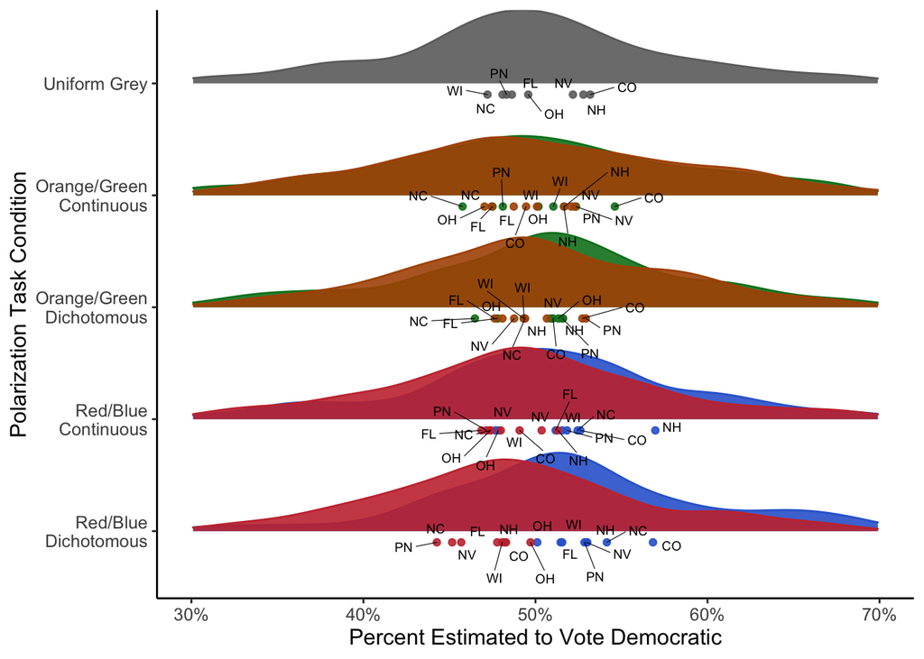

```r
dt1Graph$stateN <-as.numeric(as.factor(dt1Graph$state))
dt1Graph$stateAbbrev <-varRecode(dt1Graph$stateN,c(1,2,3,4,5,6,7,8),c("CO","FL","NV","NH","NC","OH","PN","WI"))
dt1long$task1VersionG<-varRecode(dt1long$task1Version,c("grey","redBlueDich","redBlueCont","yellowGreenDich","yellowGreenCont"),c("5. Uniform Grey","1. Red/Blue\nDichotomous","2. Red/Blue\nContinuous","3. Orange/Green\nDichotomous","4. Orange/Green\nContinuous"))
dt1Graph$task1VersionG<-varRecode(dt1Graph$task1Version,c("grey","redBlueDich","redBlueCont","yellowGreenDich","yellowGreenCont"),c("5. Uniform Grey","1. Red/Blue\nDichotomous","2. Red/Blue\nContinuous","3. Orange/Green\nDichotomous","4. Orange/Green\nContinuous"))
plot <-ggplot(dt1long,aes(x=task1PercentDemocratC,y=task1VersionG,color=colorGraph,fill=colorGraph))+
    ggridges::stat_density_ridges(scale=.7,alpha=.9)+
  geom_point(data=dt1Graph,alpha=.9,position=position_nudge(x = 0, y = -.1))+
  ggrepel::geom_text_repel(data=dt1Graph,aes(label=stateAbbrev),size=2.5,segment.size  = 0.2,segment.color = "black",color="black",position=position_nudge(x = 0, y = -.1))+
  #geom_text(data=dt1Graph,aes(label=stateN),alpha=.8)+
    scale_fill_manual(values=c("#3267D2","#077F21","#6d6d6d","#AF5303","#C8363C"))+
    scale_color_manual(values=c("#3267D2","#077F21","#6d6d6d","#AF5303","#C8363C"))+scale_y_discrete(breaks=c("5. Uniform Grey","1. Red/Blue\nDichotomous","2. Red/Blue\nContinuous","3. Orange/Green\nDichotomous","4. Orange/Green\nContinuous"),labels=c("Uniform Grey","Red/Blue\nDichotomous"," Red/Blue\nContinuous","Orange/Green\nDichotomous","Orange/Green\nContinuous"))+
  scale_x_continuous(breaks=c(-20,-10,0,10,20),labels=c("30%","40%","50%","60%","70%"),limits = c(-20,20))+
    theme(text=element_text(size=12),
        legend.position="none",panel.grid.major = element_blank(),
        panel.grid.minor = element_blank(),
        panel.background = element_blank(),
        axis.line = element_line(colour = "black"))+ylab(label="Polarization Task Condition")+xlab(label="Percent Estimated to Vote Democratic")
  #+annotate("label",label="1. Colorado\n2. Florida\n3. Nevada\n4. New Hampshire\n5. North Carolina\n6. Ohio\n7. Pennsylvania\n8. Wisconsin",x=15,y="2. Red/Blue\nContinuous",alpha=.5)


plot
```

```r
ggsave("task1_distributions_by_state.png",plot)
```

# Task 1 analyses

## Calculate each participant’s F statistic

Each participant judged the political leaning of 8 states that were randomly assigned to one of two color-coded groups. We want to know the ratio of the Sum of Squares Between groups (SSB, which is how differently the participant judged the two groups’ political leanings to be) to the Sum of Squares Within groups (SSW, which is how much variance the participant’s responses had for each of the two groups).

In other words, we want to calculate an **ANOVA** for each participant and use the resulting F statistic as our index of that participant’s estimate of how different the two groups’ politics are.

```r
for(participant in unique(dt1long$subjectID)){
  partdf <-dt1long[dt1long$subjectID==participant,] #create df for this subject

  # calculate the participant's F score and add it to our original dataframe,
  # along with SSW and SSB
  partAnovaSummary <-summary(aov(task1PercentDemocrat~color,partdf))
  dt1long[dt1long$subjectID==participant,"SSB"]<-partAnovaSummary[[1]][2][1,'Sum Sq']
  dt1long[dt1long$subjectID==participant,"SSW"]<-partAnovaSummary[[1]][2][2,'Sum Sq']
  dt1long[dt1long$subjectID==participant,"Fvalue"]<-partAnovaSummary[[1]][4][1,'F value']
}

# aggregate the data so we don't have 8 redundant rows for each participant's F stats
dt1F <-dt1long %>%
  group_by(task1Version,subjectID,Party_Likeability_Democrats,Party_Likeability_Republicans,Polarization_More_Divided_Than_Before,Polarization_Problem,Polarization_Half_Country_Ignored,Polarization_Same_Values,studyAbout,colorsThink,whichColorsT1,whichColorsT2,candidate2016,candidate2020,voterRegistrationStatus,age,gender,ethnicity,stateLiveIn,highestDegree) %>%
  dplyr::summarize(Fvalue=mean(Fvalue,na.rm=T),SSB=mean(SSB,na.rm=T),SSW=mean(SSW,na.rm=T))
```

### Calculate the actual F statistic for the 2020 election

```r
#percent of dem/rep vote that went republican. we'll pretend 3rd parties don't exist
colorado <- (42.1/(55.3+42.1))*100 #D
nevada <- (48/(48+49.8))*100 #D
wisconsin <- (48.8/(48.8+49.4))*100 #D
pennsylvania <- (49.1/(49.1+49.6))*100 #D
newHampshire <- (45.5/(45.5+52.6))*100 #D
florida <- (51.2/(51.2+47.8))*100 #R
northCarolina <- (50/(50+48.6))*100 #R
ohio <- (53.3/(53.3+45.2))*100 #R
f2020 <- data.frame("color"=c(1,1,1,1,1,2,2,2),"percentRep"=c(colorado,nevada,wisconsin,pennsylvania,newHampshire,florida,northCarolina,ohio))

# run ANOVA
summary(aov(percentRep~color,f2020))
```

```
        Df Sum Sq Mean Sq F value Pr(>F)
```

color 1 38.89 38.89 6.153 0.0478 * Residuals 6 37.92 6.32  
— Signif. codes: 0 ‘**’ 0.001 ’**’ 0.01 ’’ 0.05 ‘.’ 0.1 ’ ’ 1

## Preregistered analyses for Task 1

Do red/blue, yellow/green, and no color differ from each other? Our primary analyses are with participants’ **F values** (ratio of SSB/SSW) as the outcome variable, but secondary analyses will use **SSB** and **SSW** to clarify what type of polarization, if any, we’re getting. We planned to log-transform all 3 DVs, but ended up having to raise the F values to the 1/4 because the log transformation did not fully correct the positive skew.

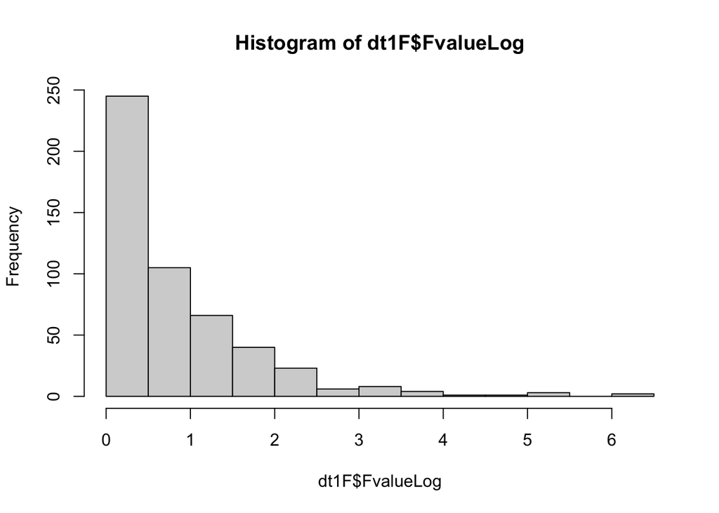

```r
dt1F$FvalueLog <-log(dt1F$Fvalue+1)
dt1F$SSBLog <-log(dt1F$SSB+1)
dt1F$SSWLog <-log(dt1F$SSW+1)

hist(dt1F$FvalueLog)
```

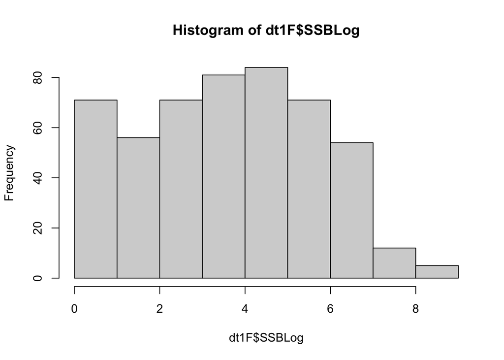

```r
hist(dt1F$SSBLog)
```

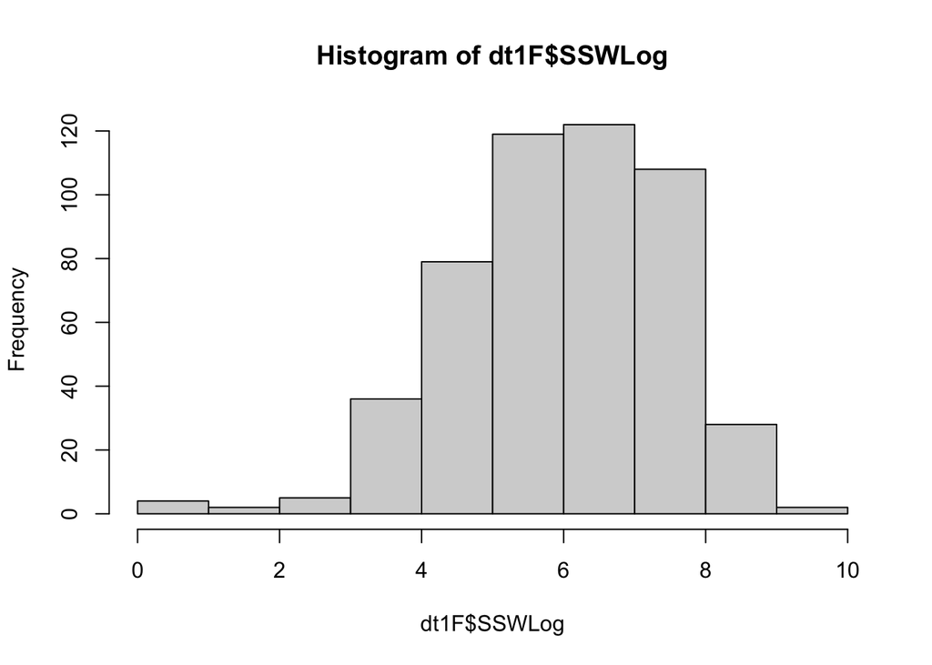

```r
hist(dt1F$SSWLog)
```

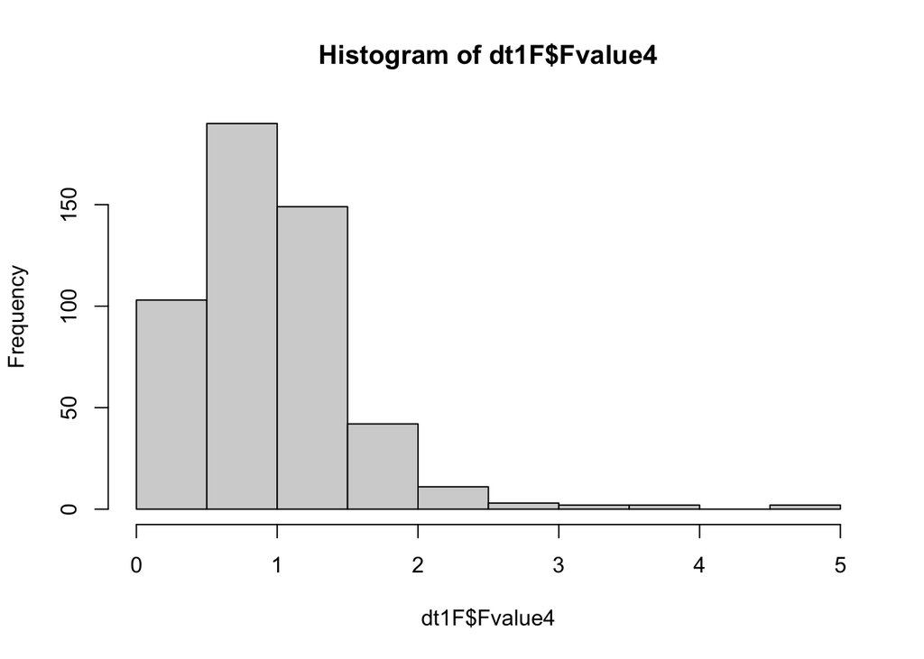

```r
# looks like we need to further transform F values because they are still quite positively skewed.
dt1F$Fvalue4 <-dt1F$Fvalue^.25
hist(dt1F$Fvalue4)
```

```r
# create a gradient variable
dt1F$colorGradient <-ifelse(grepl("Dich", dt1F$task1Version, fixed=TRUE),"dichotomous",
                        ifelse(grepl("Cont", dt1F$task1Version,
                                             fixed=TRUE),"continuous","grey"))

# create a LINEAR color scheme variable
dt1F$colorLinear <-ifelse(grepl("redBlue", dt1F$task1Version, fixed=TRUE),.5,
                        ifelse(grepl("yellowGreen", dt1F$task1Version, fixed=TRUE),0,-.5))
# make a version of the LINEAR scheme for analyses that don't include the no color condition
dt1F$colorLinear2 <-ifelse(grepl("redBlue", dt1F$task1Version, fixed=TRUE),.5,
                        ifelse(grepl("yellowGreen", dt1F$task1Version,
                                     fixed=TRUE),-.5,NA))

# create an ORTHOGONAL color scheme variable
dt1F$colorOrthogonal <-ifelse(grepl("redBlue", dt1F$task1Version, fixed=TRUE),-1.0/3.0,
                        ifelse(grepl("yellowGreen", dt1F$task1Version, fixed=TRUE),
                               2.0/3.0,-1.0/3.0))
```

### Effect of color scheme, excluding the continuous gradient conditions

For now, I’m excluding the continuous gradient data from these analyses because the “no color” condition doesn’t have an equivalent gradient manipulation.

```r
knitr::kable(varDescribeBy(dt1F$Fvalue,dt1F[,c("colorGradient","colorLinear")]))
```

|  | -0.5 | 0 | 0.5 |
| --- | --- | --- | --- |
| continuous | NULL | list(vars = 1, n = 101, mean = 1.99, sd = 4.54, median = 0.45, min = 0, max = 31.47, skew = 4.49, kurtosis = 22.48) | list(vars = 1, n = 100, mean = 4.45, sd = 15.84, median = 0.8, min = 0, max = 148.37, skew = 7.71, kurtosis = 65.63) |
| dichotomous | NULL | list(vars = 1, n = 103, mean = 1.55, sd = 3.24, median = 0.39, min = 0, max = 19.11, skew = 3.67, kurtosis = 14.84) | list(vars = 1, n = 98, mean = 17.8, sd = 69.19, median = 1.15, min = 0, max = 429.93, skew = 4.88, kurtosis = 23.91) |
| grey | list(vars = 1, n = 102, mean = 2.34, sd = 7.9, median = 0.61, min = 0, max = 75.76, skew = 8.06, kurtosis = 70.65) | NULL | NULL |

```r
knitr::kable(varDescribeBy(dt1F$SSW,dt1F[,c("colorGradient","colorLinear")]))
```

|  | -0.5 | 0 | 0.5 |
| --- | --- | --- | --- |
| continuous | NULL | list(vars = 1, n = 101, mean = 947.94, sd = 1094.94, median = 591.5, min = 25.75, max = 6180.75, skew = 2.23, kurtosis = 6.27) | list(vars = 1, n = 101, mean = 872.99, sd = 1045.26, median = 377.75, min = 0, max = 5253.5, skew = 1.83, kurtosis = 3.5) |
| dichotomous | NULL | list(vars = 1, n = 103, mean = 758.69, sd = 850.47, median = 417.75, min = 1.5, max = 4411.5, skew = 1.82, kurtosis = 3.53) | list(vars = 1, n = 98, mean = 767.66, sd = 1312.07, median = 403.13, min = 1, max = 9321.75, skew = 4.17, kurtosis = 20.62) |
| grey | list(vars = 1, n = 102, mean = 1119.7, sd = 1899.53, median = 373.25, min = 11.75, max = 15000, skew = 4.31, kurtosis = 26.09) | NULL | NULL |

```r
knitr::kable(varDescribeBy(dt1F$SSB,dt1F[,c("colorGradient","colorLinear")]))
```

|  | -0.5 | 0 | 0.5 |
| --- | --- | --- | --- |
| continuous | NULL | list(vars = 1, n = 101, mean = 162.36, sd = 301.59, median = 40.5, min = 0.12, max = 2211.12, skew = 3.81, kurtosis = 19.77) | list(vars = 1, n = 101, mean = 257.3, sd = 750.48, median = 60.5, min = 0, max = 7140.12, skew = 7.71, kurtosis = 67.15) |
| dichotomous | NULL | list(vars = 1, n = 103, mean = 122.18, sd = 292.29, median = 21.12, min = 0, max = 1860.5, skew = 4, kurtosis = 16.94) | list(vars = 1, n = 98, mean = 420.77, sd = 1001.47, median = 60.63, min = 0, max = 6216.12, skew = 4.02, kurtosis = 17.63) |
| grey | list(vars = 1, n = 102, mean = 200.51, sd = 563.53, median = 36.12, min = 0, max = 5000, skew = 6.53, kurtosis = 50.03) | NULL | NULL |

#### Effect of color scheme on log-transformed F values, dichotomous colors only

```r
modFcolor <-lm(FvalueLog~colorLinear+colorOrthogonal,data=dt1F[dt1F$colorGradient!="continuous",])
summary(modFcolor)
```

Call: lm(formula = FvalueLog ~ colorLinear + colorOrthogonal, data = dt1F[dt1F$colorGradient != “continuous”, ])

Residuals: Min 1Q Median 3Q Max -1.1707 -0.5891 -0.2750 0.3812 4.8953

Coefficients: Estimate Std. Error t value Pr(>|t|)  
(Intercept) 0.82495 0.05553 14.856 < 2e-16 *colorLinear 0.45921 0.13669 3.359 0.000882* colorOrthogonal -0.34843 0.11721 -2.973 0.003192 ** — Signif. codes: 0 ‘**’ 0.001 ’**’ 0.01 ’’ 0.05 ‘.’ 0.1 ’ ’ 1

Residual standard error: 0.9664 on 300 degrees of freedom Multiple R-squared: 0.06218, Adjusted R-squared: 0.05593 F-statistic: 9.946 on 2 and 300 DF, p-value: 6.571e-05

```r
modelEffectSizes(modFcolor)
```

lm(formula = FvalueLog ~ colorLinear + colorOrthogonal, data = dt1F[dt1F$colorGradient != “continuous”, ])

Coefficients SSR df pEta-sqr dR-sqr (Intercept) 206.1085 1 0.4239 NA colorLinear 10.5395 1 0.0363 0.0353 colorOrthogonal 8.2525 1 0.0286 0.0276

Sum of squared errors (SSE): 280.2 Sum of squared total (SST): 298.7

#### Effect of color scheme on F values, dichotomous colors only, with F values to the 1/4 instead of log

```r
modFcolor4 <-lm(Fvalue4~colorLinear+colorOrthogonal,data=dt1F[dt1F$colorGradient!="continuous",])
summary(modFcolor4)
```

Call: lm(formula = Fvalue4 ~ colorLinear + colorOrthogonal, data = dt1F[dt1F$colorGradient != “continuous”, ])

Residuals: Min 1Q Median 3Q Max -1.1972 -0.3875 -0.0507 0.2626 3.3564

Coefficients: Estimate Std. Error t value Pr(>|t|)  
(Intercept) 0.97438 0.03467 28.105 < 2e-16 **colorLinear 0.27816 0.08534 3.259 0.001245** colorOrthogonal -0.25108 0.07318 -3.431 0.000686 ** — Signif. codes: 0 ‘**’ 0.001 ’**’ 0.01 ’’ 0.05 ‘.’ 0.1 ’ ’ 1

Residual standard error: 0.6033 on 300 degrees of freedom Multiple R-squared: 0.06872, Adjusted R-squared: 0.06251 F-statistic: 11.07 on 2 and 300 DF, p-value: 2.301e-05

```r
modelEffectSizes(modFcolor4)
```

lm(formula = Fvalue4 ~ colorLinear + colorOrthogonal, data = dt1F[dt1F$colorGradient != “continuous”, ])

Coefficients SSR df pEta-sqr dR-sqr (Intercept) 287.5409 1 0.7247 NA colorLinear 3.8670 1 0.0342 0.0330 colorOrthogonal 4.2853 1 0.0378 0.0365

Sum of squared errors (SSE): 109.2 Sum of squared total (SST): 117.3

#### Effect of color scheme on Sum of Squares Within, dichotomous colors only

```r
modSSWcolor<-lm(SSWLog~colorLinear+colorOrthogonal,data=dt1F[dt1F$colorGradient!="continuous",])
summary(modSSWcolor)
```

Call: lm(formula = SSWLog ~ colorLinear + colorOrthogonal, data = dt1F[dt1F$colorGradient != “continuous”, ])

Residuals: Min 1Q Median 3Q Max -5.0976 -0.9902 0.1048 1.1464 3.6302

Coefficients: Estimate Std. Error t value Pr(>|t|)  
(Intercept) 5.90274 0.08347 70.719 <2e-16 *** colorLinear -0.19488 0.20547 -0.948 0.344  
colorOrthogonal 0.04366 0.17618 0.248 0.804  
— Signif. codes: 0 ‘**’ 0.001 ’**’ 0.01 ’’ 0.05 ‘.’ 0.1 ’ ’ 1

Residual standard error: 1.453 on 300 degrees of freedom Multiple R-squared: 0.003175, Adjusted R-squared: -0.00347 F-statistic: 0.4778 on 2 and 300 DF, p-value: 0.6206

```r
modelEffectSizes(modSSWcolor)
```

lm(formula = SSWLog ~ colorLinear + colorOrthogonal, data = dt1F[dt1F$colorGradient != “continuous”, ])

Coefficients SSR df pEta-sqr dR-sqr (Intercept) 10552.3523 1 0.9434 NA colorLinear 1.8981 1 0.0030 3e-03 colorOrthogonal 0.1296 1 0.0002 2e-04

Sum of squared errors (SSE): 633.0 Sum of squared total (SST): 635.0

#### Effect of color scheme on Sum of Squares Between

```r
modSSBcolor<-lm(SSBLog~colorLinear+colorOrthogonal,data=dt1F[dt1F$colorGradient!="continuous",])
summary(modSSBcolor)
```

Call: lm(formula = SSBLog ~ colorLinear + colorOrthogonal, data = dt1F[dt1F$colorGradient != “continuous”, ])

Residuals: Min 1Q Median 3Q Max -4.1516 -1.4338 -0.0167 1.5559 4.8864

Coefficients: Estimate Std. Error t value Pr(>|t|)  
(Intercept) 3.6116 0.1179 30.631 < 2e-16 colorLinear 0.5206 0.2902 1.794 0.073852 .  
colorOrthogonal -0.8392 0.2489 -3.372 0.000844 — Signif. codes: 0 ‘**’ 0.001 ’**’ 0.01 ’’ 0.05 ‘.’ 0.1 ’ ’ 1

Residual standard error: 2.052 on 300 degrees of freedom Multiple R-squared: 0.04595, Adjusted R-squared: 0.03959 F-statistic: 7.225 on 2 and 300 DF, p-value: 0.0008619

```r
modelEffectSizes(modSSBcolor)
```

lm(formula = SSBLog ~ colorLinear + colorOrthogonal, data = dt1F[dt1F$colorGradient != “continuous”, ])

Coefficients SSR df pEta-sqr dR-sqr (Intercept) 3950.2992 1 0.7577 NA colorLinear 13.5473 1 0.0106 0.0102 colorOrthogonal 47.8757 1 0.0365 0.0362

Sum of squared errors (SSE): 1263.1 Sum of squared total (SST): 1323.9

### Effect of gradient, excluding the No Color condition

Among the colored maps, does gradient have an effect?

#### Effect of color gradient on F values (log-transformed)

```r
dt1F$colorGradientN <-varRecode(dt1F$colorGradient,c("dichotomous","continuous","grey"),c(.5,-.5,NA))
modFgrad <-lm(FvalueLog~colorLinear2*colorGradientN,data=dt1F)
summary(modFgrad)
```

Call: lm(formula = FvalueLog ~ colorLinear2 * colorGradientN, data = dt1F)

Residuals: Min 1Q Median 3Q Max -1.1707 -0.5927 -0.3036 0.3600 4.8953

Coefficients: Estimate Std. Error t value Pr(>|t|)  
(Intercept) 0.83678 0.04823 17.349 < 2e-16 *colorLinear2 0.39961 0.09646 4.143 4.2e-05* colorGradientN 0.08981 0.09646 0.931 0.3524  
colorLinear2:colorGradientN 0.35685 0.19293 1.850 0.0651 .  
— Signif. codes: 0 ‘**’ 0.001 ’**’ 0.01 ’’ 0.05 ‘.’ 0.1 ’ ’ 1

Residual standard error: 0.9669 on 398 degrees of freedom (103 observations deleted due to missingness) Multiple R-squared: 0.05085, Adjusted R-squared: 0.04369 F-statistic: 7.107 on 3 and 398 DF, p-value: 0.0001161

```r
modelEffectSizes(modFgrad)
```

lm(formula = FvalueLog ~ colorLinear2 * colorGradientN, data = dt1F)

Coefficients SSR df pEta-sqr dR-sqr (Intercept) 281.3876 1 0.4306 NA colorLinear2 16.0431 1 0.0413 0.0409 colorGradientN 0.8104 1 0.0022 0.0021 colorLinear2:colorGradientN 3.1985 1 0.0085 0.0082

Sum of squared errors (SSE): 372.1 Sum of squared total (SST): 392.0 #### Effect of color gradient on F values to the 1/4 instead of log

```r
modFgrad4 <-lm(Fvalue4~colorLinear2*colorGradientN,data=dt1F)
summary(modFgrad4)
```

Call: lm(formula = Fvalue4 ~ colorLinear2 * colorGradientN, data = dt1F)

Residuals: Min 1Q Median 3Q Max -1.1972 -0.3807 -0.0637 0.2567 3.3564

Coefficients: Estimate Std. Error t value Pr(>|t|)  
(Intercept) 0.97693 0.02972 32.875 <2e-16 *colorLinear2 0.24108 0.05943 4.056 6e-05* colorGradientN 0.05030 0.05943 0.846 0.3979  
colorLinear2:colorGradientN 0.29815 0.11886 2.508 0.0125 *  
— Signif. codes: 0 ‘**’ 0.001 ’**’ 0.01 ’’ 0.05 ‘.’ 0.1 ’ ’ 1

Residual standard error: 0.5957 on 398 degrees of freedom (103 observations deleted due to missingness) Multiple R-squared: 0.05537, Adjusted R-squared: 0.04825 F-statistic: 7.777 on 3 and 398 DF, p-value: 4.662e-05

```r
modelEffectSizes(modFgrad4)
```

lm(formula = Fvalue4 ~ colorLinear2 * colorGradientN, data = dt1F)

Coefficients SSR df pEta-sqr dR-sqr (Intercept) 383.5385 1 0.7309 NA colorLinear2 5.8391 1 0.0397 0.0391 colorGradientN 0.2542 1 0.0018 0.0017 colorLinear2:colorGradientN 2.2328 1 0.0156 0.0149

Sum of squared errors (SSE): 141.2 Sum of squared total (SST): 149.5

#### Post-hoc simple effects estimates

We’ll recenter the predictor variables in the regression to test the simple effects

```r
dt1F$colorLinear2continuous <-dt1F$colorLinear2+.5
dt1F$colorLinear2discrete <-dt1F$colorLinear2-.5

# simple effect of color scale for continuous color gradient
modFgrad4simplecontinuous <-lm(Fvalue4~colorLinear2continuous*colorGradientN,data=dt1F)
summary(modFgrad4simplecontinuous)
```

Call: lm(formula = Fvalue4 ~ colorLinear2continuous * colorGradientN, data = dt1F)

Residuals: Min 1Q Median 3Q Max -1.1972 -0.3807 -0.0637 0.2567 3.3564

Coefficients: Estimate Std. Error t value Pr(>|t|)  
(Intercept) 0.85639 0.04171 20.532 <2e-16 *colorLinear2continuous 0.24108 0.05943 4.056 6e-05* colorGradientN -0.09878 0.08342 -1.184 0.2371  
colorLinear2continuous:colorGradientN 0.29815 0.11886 2.508 0.0125 *  
— Signif. codes: 0 ‘**’ 0.001 ’**’ 0.01 ’’ 0.05 ‘.’ 0.1 ’ ’ 1

Residual standard error: 0.5957 on 398 degrees of freedom (103 observations deleted due to missingness) Multiple R-squared: 0.05537, Adjusted R-squared: 0.04825 F-statistic: 7.777 on 3 and 398 DF, p-value: 4.662e-05

```r
modelEffectSizes(modFgrad4simplecontinuous)
```

lm(formula = Fvalue4 ~ colorLinear2continuous * colorGradientN, data = dt1F)

Coefficients SSR df pEta-sqr dR-sqr (Intercept) 149.5985 1 0.5144 NA colorLinear2continuous 5.8391 1 0.0397 0.0391 colorGradientN 0.4976 1 0.0035 0.0033 colorLinear2continuous:colorGradientN 2.2328 1 0.0156 0.0149

Sum of squared errors (SSE): 141.2 Sum of squared total (SST): 149.5

```r
#simple effect of color scale for discrete color gradient
modFgrad4simplediscrete <-lm(Fvalue4~colorLinear2discrete*colorGradientN,data=dt1F)
summary(modFgrad4simplediscrete)
```

Call: lm(formula = Fvalue4 ~ colorLinear2discrete * colorGradientN, data = dt1F)

Residuals: Min 1Q Median 3Q Max -1.1972 -0.3807 -0.0637 0.2567 3.3564

Coefficients: Estimate Std. Error t value Pr(>|t|)  
(Intercept) 1.09746 0.04234 25.922 <2e-16 *colorLinear2discrete 0.24108 0.05943 4.056 6e-05* colorGradientN 0.19938 0.08468 2.355 0.0190 *  
colorLinear2discrete:colorGradientN 0.29815 0.11886 2.508 0.0125 *  
— Signif. codes: 0 ‘**’ 0.001 ’**’ 0.01 ’’ 0.05 ‘.’ 0.1 ’ ’ 1

Residual standard error: 0.5957 on 398 degrees of freedom (103 observations deleted due to missingness) Multiple R-squared: 0.05537, Adjusted R-squared: 0.04825 F-statistic: 7.777 on 3 and 398 DF, p-value: 4.662e-05

```r
modelEffectSizes(modFgrad4simplediscrete)
```

lm(formula = Fvalue4 ~ colorLinear2discrete * colorGradientN, data = dt1F)

Coefficients SSR df pEta-sqr dR-sqr (Intercept) 238.4526 1 0.6280 NA colorLinear2discrete 5.8391 1 0.0397 0.0391 colorGradientN 1.9675 1 0.0137 0.0132 colorLinear2discrete:colorGradientN 2.2328 1 0.0156 0.0149

Sum of squared errors (SSE): 141.2 Sum of squared total (SST): 149.5

#### Effect of color gradient on Sum of Squares Within

```r
modSSWgrad<-lm(SSWLog~colorLinear2*colorGradientN,data=dt1F)
summary(modSSWgrad)
```

Call: lm(formula = SSWLog ~ colorLinear2 * colorGradientN, data = dt1F)

Residuals: Min 1Q Median 3Q Max -5.9200 -0.9381 0.1143 1.0736 3.3495

Coefficients: Estimate Std. Error t value Pr(>|t|)  
(Intercept) 5.95870 0.07091 84.027 <2e-16 *** colorLinear2 -0.20662 0.14183 -1.457 0.146  
colorGradientN -0.19480 0.14183 -1.373 0.170  
colorLinear2:colorGradientN 0.13105 0.28366 0.462 0.644  
— Signif. codes: 0 ‘**’ 0.001 ’**’ 0.01 ’’ 0.05 ‘.’ 0.1 ’ ’ 1

Residual standard error: 1.423 on 399 degrees of freedom (102 observations deleted due to missingness) Multiple R-squared: 0.0104, Adjusted R-squared: 0.002958 F-statistic: 1.398 on 3 and 399 DF, p-value: 0.2431

```r
modelEffectSizes(modSSWgrad)
```

lm(formula = SSWLog ~ colorLinear2 * colorGradientN, data = dt1F)

Coefficients SSR df pEta-sqr dR-sqr (Intercept) 14304.4307 1 0.9465 NA colorLinear2 4.2999 1 0.0053 0.0053 colorGradientN 3.8218 1 0.0047 0.0047 colorLinear2:colorGradientN 0.4324 1 0.0005 0.0005

Sum of squared errors (SSE): 808.4 Sum of squared total (SST): 816.9

#### Effect of color gradient on Sum of Squares Between

```r
modSSBgrad<-lm(SSBLog~colorLinear2*colorGradientN,data=dt1F)
summary(modSSBgrad)
```

Call: lm(formula = SSBLog ~ colorLinear2 * colorGradientN, data = dt1F)

Residuals: Min 1Q Median 3Q Max -4.1516 -1.4805 0.1389 1.5753 5.1103

Coefficients: Estimate Std. Error t value Pr(>|t|)  
(Intercept) 3.6612 0.1034 35.409 < 2e-16 **colorLinear2 0.5926 0.2068 2.866 0.00438** colorGradientN -0.1187 0.2068 -0.574 0.56636  
colorLinear2:colorGradientN 1.0138 0.4136 2.451 0.01466  
— Signif. codes: 0 ‘**’ 0.001 ’**’ 0.01 ’’ 0.05 ‘.’ 0.1 ’ ’ 1

Residual standard error: 2.075 on 399 degrees of freedom (102 observations deleted due to missingness) Multiple R-squared: 0.03528, Adjusted R-squared: 0.02803 F-statistic: 4.864 on 3 and 399 DF, p-value: 0.002466

```r
modelEffectSizes(modSSBgrad)
```

lm(formula = SSBLog ~ colorLinear2 * colorGradientN, data = dt1F)

Coefficients SSR df pEta-sqr dR-sqr (Intercept) 5400.2034 1 0.7586 NA colorLinear2 35.3709 1 0.0202 0.0199 colorGradientN 1.4185 1 0.0008 0.0008 colorLinear2:colorGradientN 25.8814 1 0.0148 0.0145

Sum of squared errors (SSE): 1718.5 Sum of squared total (SST): 1781.3

## Plot the Task 1 F values by condition

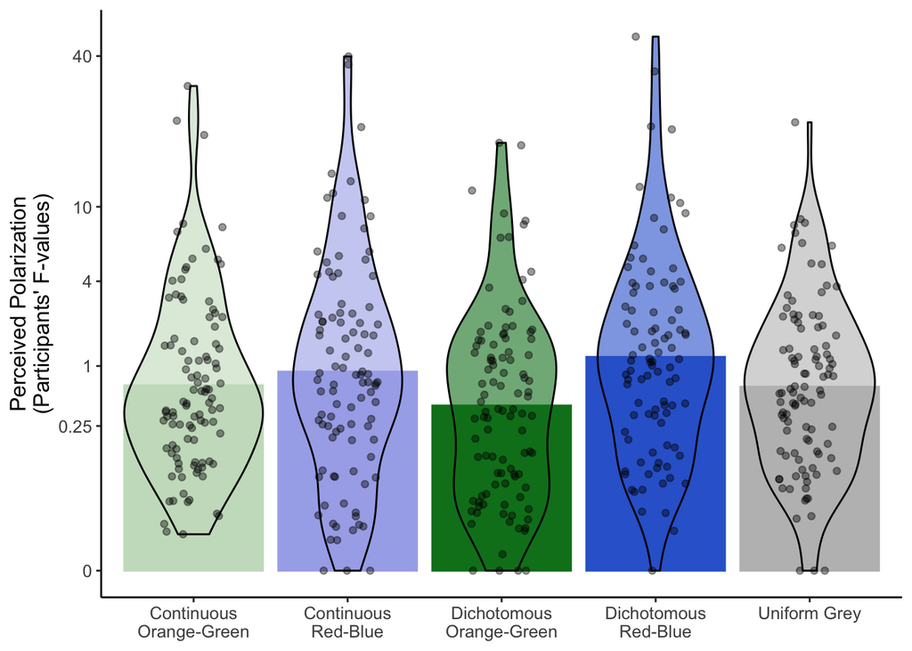

```r
# remove extreme F value outliers for the sake of the graph (+3 SDs)
dfPlot <-dt1F[dt1F$Fvalue4<=mean(dt1F$Fvalue4,na.rm=T)+3*sd(dt1F$Fvalue4,na.rm=T),]
dfPlot$task1Version <-varRecode(dfPlot$task1Version,c("grey","redBlueCont","redBlueDich","yellowGreenCont","yellowGreenDich"),c("Uniform Grey","Continuous\nRed-Blue","Dichotomous\nRed-Blue","Continuous\nOrange-Green","Dichotomous\nOrange-Green"))
dfPlot$task1Version<-as.factor(dfPlot$task1Version)
dfPlot <-dfPlot[!is.na(dfPlot$task1Version),]
plotF <-ggplot(data=dfPlot,aes(x=task1Version,y=Fvalue4,fill=task1Version,color=task1Version))+
  geom_bar(stat="summary",fun.y="mean", position="dodge")+
  geom_violin(stat="ydensity",position="dodge",color="black",alpha=.6)+
  geom_point(position=position_jitter(width=.2),alpha=.4,color="black",fill="black")+theme_classic()+
  theme(text=element_text(size=12),axis.title.x=element_blank(),
        legend.position="none",panel.grid.major = element_blank(),
        panel.grid.minor = element_blank(),
        panel.background = element_blank(),
        axis.line = element_line(colour = "black"))+
  ylab("Perceived Polarization\n(Participants' F-values)")+
  scale_fill_manual(values=c("#C9DFC5","#A8AFEA","#077F21","#3267D2","grey"))+
  scale_color_manual(values=c("#C9DFC5","#A8AFEA","#077F21","#3267D2","grey"))+
    scale_y_continuous(breaks=c(0,.25^.25,1^.25,  4^.25,10^.25,40^.25),labels=c(0,.25,1,4,10,40))
plotF
```

```r
ggsave("task1_results.png",plotF,width=5,height=4)
```

### 2x2 plot for manuscript

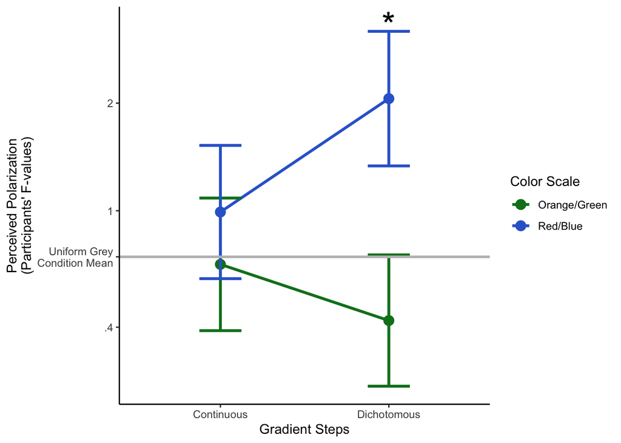

```r
dt1F$colorGradientGraph <-as.factor(dt1F$colorGradientN)
dt1F$colorLinearGraph <-as.factor(dt1F$colorLinear2)
modFgrad4plot <-lm(Fvalue4~colorLinearGraph*colorGradientGraph,data=dt1F)
int_plot <-cat_plot(modFgrad4plot,pred=colorGradientGraph,modx=colorLinearGraph,pred.values=c("-0.5","0.5"),modx.values=c("-0.5","0.5"),x.label="Gradient Steps",y.label="Perceived Polarization\n(Participants' F-values)",legend.main="Color Scale", pred.labels=c("Continuous","Dichotomous"),modx.labels=c("Orange/Green","Red/Blue"),colors=c("#077F21","#3267D2"),int.type="prediction",geom="line")+
  geom_hline(yintercept=mean(dt1F[dt1F$task1Version=="grey",]$Fvalue4,na.rm=T),size=1,color="grey")+scale_y_continuous(breaks=c(.02^(1/4), .12^(1/4), .4^(1/4), mean(dt1F[dt1F$task1Version=="grey",]$Fvalue4,na.rm=T), 1, 2^(1/4), 4^(1/4)),labels=c(".02",".12",".4","Uniform Grey\nCondition Mean","1","2","4"))+annotate("text",x=2,y=3.1^(1/4),label="*",size=10) +theme_classic()
int_plot
```

```r
ggsave("interaction_plot_polarization.png",int_plot,width=5,height=3.5)
```

## Exploratory analyses for Task 1

Do Biden and Trump voters think of polarization as similarly problematic?

```r
#1 joe biden #2 donald trump
dt1F$candidate2020N <-varRecode(dt1F$candidate2020,c(1,2,3),c(.5,-.5,NA))
```

```r
knitr::kable(varDescribeBy(demographicDF$Polarization_More_Divided_Than_Before,demographicDF[,c("candidate2020","gender")]),caption="Polarization_More_Divided_Than_Before")
```

Polarization_More_Divided_Than_Before

|  | Female | Male | Other | Transgender Male |
| --- | --- | --- | --- | --- |
| Biden | list(vars = 1, n = 83, mean = 6.04, sd = 0.96, median = 6, min = 3, max = 7, skew = -0.82, kurtosis = 0.1) | list(vars = 1, n = 129, mean = 5.6, sd = 1.38, median = 6, min = 1, max = 7, skew = -1.16, kurtosis = 1.08) | list(vars = 1, n = 1, mean = 2, sd = NA, median = 2, min = 2, max = 2, skew = NA, kurtosis = NA) | list(vars = 1, n = 1, mean = 6, sd = NA, median = 6, min = 6, max = 6, skew = NA, kurtosis = NA) |
| Neither | list(vars = 1, n = 4, mean = 5, sd = 1.41, median = 5.5, min = 3, max = 6, skew = -0.53, kurtosis = -1.88) | list(vars = 1, n = 15, mean = 5.47, sd = 1.46, median = 6, min = 2, max = 7, skew = -0.91, kurtosis = 0.02) | NULL | NULL |
| Trump | list(vars = 1, n = 82, mean = 5.61, sd = 1.14, median = 6, min = 1, max = 7, skew = -1.37, kurtosis = 3.02) | list(vars = 1, n = 153, mean = 5.4, sd = 1.07, median = 5, min = 2, max = 7, skew = -0.55, kurtosis = 0.09) | NULL | NULL |

```r
knitr::kable(varDescribeBy(demographicDF$Polarization_Half_Country_Ignored,demographicDF[,c("candidate2020","gender")]),caption="Polarization_Half_Country_Ignored")
```

Polarization_Half_Country_Ignored

|  | Female | Male | Other | Transgender Male |
| --- | --- | --- | --- | --- |
| Biden | list(vars = 1, n = 83, mean = 5.35, sd = 1.42, median = 5, min = 2, max = 7, skew = -0.65, kurtosis = -0.31) | list(vars = 1, n = 129, mean = 4.89, sd = 1.53, median = 5, min = 1, max = 7, skew = -0.49, kurtosis = -0.45) | list(vars = 1, n = 1, mean = 6, sd = NA, median = 6, min = 6, max = 6, skew = NA, kurtosis = NA) | list(vars = 1, n = 1, mean = 6, sd = NA, median = 6, min = 6, max = 6, skew = NA, kurtosis = NA) |
| Neither | list(vars = 1, n = 4, mean = 4.75, sd = 1.89, median = 5.5, min = 2, max = 6, skew = -0.62, kurtosis = -1.79) | list(vars = 1, n = 15, mean = 5.8, sd = 0.77, median = 6, min = 4, max = 7, skew = -0.55, kurtosis = -0.06) | NULL | NULL |
| Trump | list(vars = 1, n = 82, mean = 5.35, sd = 1.36, median = 6, min = 1, max = 7, skew = -0.85, kurtosis = 0.45) | list(vars = 1, n = 153, mean = 5.48, sd = 1.32, median = 6, min = 2, max = 7, skew = -0.93, kurtosis = 0.52) | NULL | NULL |

```r
knitr::kable(varDescribeBy(demographicDF$Polarization_Problem,demographicDF[,c("candidate2020","gender")]),caption="Polarization_Problem")
```

Polarization_Problem

|  | Female | Male | Other | Transgender Male |
| --- | --- | --- | --- | --- |
| Biden | list(vars = 1, n = 83, mean = 5.87, sd = 1.29, median = 6, min = 2, max = 7, skew = -1.22, kurtosis = 1.01) | list(vars = 1, n = 129, mean = 5.66, sd = 1.46, median = 6, min = 1, max = 7, skew = -1.06, kurtosis = 0.44) | list(vars = 1, n = 1, mean = 7, sd = NA, median = 7, min = 7, max = 7, skew = NA, kurtosis = NA) | list(vars = 1, n = 1, mean = 7, sd = NA, median = 7, min = 7, max = 7, skew = NA, kurtosis = NA) |
| Neither | list(vars = 1, n = 4, mean = 5.5, sd = 1.29, median = 5.5, min = 4, max = 7, skew = 0, kurtosis = -2.08) | list(vars = 1, n = 15, mean = 5.8, sd = 1.57, median = 6, min = 2, max = 7, skew = -1.15, kurtosis = 0.16) | NULL | NULL |
| Trump | list(vars = 1, n = 82, mean = 5.24, sd = 1.26, median = 5, min = 1, max = 7, skew = -0.6, kurtosis = 0.19) | list(vars = 1, n = 153, mean = 5.45, sd = 1.22, median = 6, min = 1, max = 7, skew = -0.67, kurtosis = 0.32) | NULL | NULL |

```r
knitr::kable(varDescribeBy(demographicDF$Polarization_Same_Values,demographicDF[,c("candidate2020","gender")]),caption="Polarization_Same_Values")
```

Polarization_Same_Values

|  | Female | Male | Other | Transgender Male |
| --- | --- | --- | --- | --- |
| Biden | list(vars = 1, n = 83, mean = 4.13, sd = 1.71, median = 4, min = 1, max = 7, skew = -0.04, kurtosis = -1.11) | list(vars = 1, n = 129, mean = 4.5, sd = 1.52, median = 5, min = 1, max = 7, skew = -0.24, kurtosis = -0.83) | list(vars = 1, n = 1, mean = 2, sd = NA, median = 2, min = 2, max = 2, skew = NA, kurtosis = NA) | list(vars = 1, n = 1, mean = 2, sd = NA, median = 2, min = 2, max = 2, skew = NA, kurtosis = NA) |
| Neither | list(vars = 1, n = 4, mean = 3.25, sd = 1.26, median = 3, min = 2, max = 5, skew = 0.42, kurtosis = -1.82) | list(vars = 1, n = 15, mean = 4.33, sd = 1.68, median = 5, min = 1, max = 7, skew = -0.49, kurtosis = -0.86) | NULL | NULL |
| Trump | list(vars = 1, n = 82, mean = 4.91, sd = 1.73, median = 5, min = 1, max = 7, skew = -0.77, kurtosis = -0.22) | list(vars = 1, n = 153, mean = 5.26, sd = 1.41, median = 6, min = 1, max = 7, skew = -0.99, kurtosis = 0.56) | NULL | NULL |

### Do Biden and Trump voters respond differently to the different color schemes?

```r
modF2020 <-lm(Fvalue4~colorLinear2*colorGradientN*candidate2020N,data=dt1F)
summary(modF2020)
```

Call: lm(formula = Fvalue4 ~ colorLinear2 * colorGradientN * candidate2020N, data = dt1F)

Residuals: Min 1Q Median 3Q Max -1.1209 -0.3570 -0.0616 0.2334 3.2382

Coefficients: Estimate Std. Error t value Pr(>|t|) (Intercept) 0.986078 0.031342 31.461 < 2e-16 colorLinear2 0.240494 0.062685 3.837 0.000148 colorGradientN 0.029938 0.062685 0.478 0.633236 candidate2020N 0.008775 0.062685 0.140 0.888750 colorLinear2:colorGradientN 0.261776 0.125370 2.088 0.037522 colorLinear2:candidate2020N 0.181977 0.125370 1.452 0.147535 colorGradientN:candidate2020N 0.236633 0.125370 1.887 0.059928 colorLinear2:colorGradientN:candidate2020N 0.156926 0.250739 0.626 0.531822

(Intercept) *colorLinear2* colorGradientN  
candidate2020N  
colorLinear2:colorGradientN *  
colorLinear2:candidate2020N  
colorGradientN:candidate2020N .  
colorLinear2:colorGradientN:candidate2020N  
— Signif. codes: 0 ‘**’ 0.001 ’**’ 0.01 ’’ 0.05 ‘.’ 0.1 ’ ’ 1

Residual standard error: 0.5908 on 348 degrees of freedom (149 observations deleted due to missingness) Multiple R-squared: 0.06715, Adjusted R-squared: 0.04839 F-statistic: 3.579 on 7 and 348 DF, p-value: 0.0009832

```r
modelEffectSizes(modF2020)
```

lm(formula = Fvalue4 ~ colorLinear2 * colorGradientN * candidate2020N, data = dt1F)

Coefficients SSR df pEta-sqr dR-sqr (Intercept) 345.4986 1 0.7399 NA colorLinear2 5.1377 1 0.0406 0.0395 colorGradientN 0.0796 1 0.0007 0.0006 candidate2020N 0.0068 1 0.0001 0.0001 colorLinear2:colorGradientN 1.5218 1 0.0124 0.0117 colorLinear2:candidate2020N 0.7354 1 0.0060 0.0056 colorGradientN:candidate2020N 1.2435 1 0.0101 0.0095 colorLinear2:colorGradientN:candidate2020N 0.1367 1 0.0011 0.0010

Sum of squared errors (SSE): 121.5 Sum of squared total (SST): 130.2

```r
knitr::kable(varDescribeBy(dt1F$Fvalue,dt1F[,c("colorGradientN","candidate2020N")]))
```

|  | -0.5 | 0.5 |
| --- | --- | --- |
| -0.5 | list(vars = 1, n = 89, mean = 4.49, sd = 16.55, median = 0.71, min = 0, max = 148.37, skew = 7.53, kurtosis = 61.48) | list(vars = 1, n = 91, mean = 2.04, sd = 3.84, median = 0.68, min = 0, max = 23.39, skew = 3.74, kurtosis = 16.3) |
| 0.5 | list(vars = 1, n = 92, mean = 4.7, sd = 25.19, median = 0.78, min = 0, max = 239.02, skew = 8.78, kurtosis = 78.47) | list(vars = 1, n = 84, mean = 15.64, sd = 69.82, median = 0.88, min = 0, max = 429.93, skew = 5.23, kurtosis = 26.67) |

### Polarization self-reported concern predicting Task 1 polarization scores

The self-report polarization items aren’t so correlated that I want to combine them…

```r
cor(dt1F[,c("Polarization_More_Divided_Than_Before","Polarization_Problem","Polarization_Half_Country_Ignored","Polarization_Same_Values")],use="pairwise.complete.obs")
```

```
                                  Polarization_More_Divided_Than_Before
```

Polarization_More_Divided_Than_Before 1.0000000 Polarization_Problem 0.5042437 Polarization_Half_Country_Ignored 0.2027358 Polarization_Same_Values -0.1628877 Polarization_Problem Polarization_More_Divided_Than_Before 0.5042437 Polarization_Problem 1.0000000 Polarization_Half_Country_Ignored 0.2731744 Polarization_Same_Values -0.1927780 Polarization_Half_Country_Ignored Polarization_More_Divided_Than_Before 0.2027358 Polarization_Problem 0.2731744 Polarization_Half_Country_Ignored 1.0000000 Polarization_Same_Values 0.1281643 Polarization_Same_Values Polarization_More_Divided_Than_Before -0.1628877 Polarization_Problem -0.1927780 Polarization_Half_Country_Ignored 0.1281643 Polarization_Same_Values 1.0000000

```r
modFpol<-lm(Fvalue4~colorLinear2*colorGradientN+Polarization_More_Divided_Than_Before+Polarization_Problem+Polarization_Half_Country_Ignored+Polarization_Same_Values,data=dt1F)
summary(modFpol)
```

Call: lm(formula = Fvalue4 ~ colorLinear2 * colorGradientN + Polarization_More_Divided_Than_Before + Polarization_Problem + Polarization_Half_Country_Ignored + Polarization_Same_Values, data = dt1F)

Residuals: Min 1Q Median 3Q Max -1.2609 -0.3751 -0.0636 0.2515 3.3302

Coefficients: Estimate Std. Error t value Pr(>|t|)  
(Intercept) 0.859068 0.209808 4.095 5.15e-05 *colorLinear2 0.246015 0.060534 4.064 5.84e-05* colorGradientN 0.053526 0.060288 0.888 0.3752  
Polarization_More_Divided_Than_Before 0.010427 0.030259 0.345 0.7306  
Polarization_Problem 0.028111 0.027365 1.027 0.3049  
Polarization_Half_Country_Ignored -0.005967 0.022922 -0.260 0.7947  
Polarization_Same_Values -0.012816 0.019381 -0.661 0.5088  
colorLinear2:colorGradientN 0.305011 0.121209 2.516 0.0123 *  
— Signif. codes: 0 ‘**’ 0.001 ’**’ 0.01 ’’ 0.05 ‘.’ 0.1 ’ ’ 1

Residual standard error: 0.5974 on 388 degrees of freedom (109 observations deleted due to missingness) Multiple R-squared: 0.06187, Adjusted R-squared: 0.04494 F-statistic: 3.655 on 7 and 388 DF, p-value: 0.0007781

```r
modelEffectSizes(modF2020)
```

lm(formula = Fvalue4 ~ colorLinear2 * colorGradientN * candidate2020N, data = dt1F)

Coefficients SSR df pEta-sqr dR-sqr (Intercept) 345.4986 1 0.7399 NA colorLinear2 5.1377 1 0.0406 0.0395 colorGradientN 0.0796 1 0.0007 0.0006 candidate2020N 0.0068 1 0.0001 0.0001 colorLinear2:colorGradientN 1.5218 1 0.0124 0.0117 colorLinear2:candidate2020N 0.7354 1 0.0060 0.0056 colorGradientN:candidate2020N 1.2435 1 0.0101 0.0095 colorLinear2:colorGradientN:candidate2020N 0.1367 1 0.0011 0.0010

Sum of squared errors (SSE): 121.5 Sum of squared total (SST): 130.2 ***

# Task 2

### Study design

Participants’ color assignments transfer from Task 1 and they are randomly assigned to make judgments about either a Republican majority county or a Democratic majority county.

|  | Red/blue | Yellow/green | No color |
| --- | --- | --- | --- |
| Republican Majority | R majority (red) | R majority (yellow) | R majority (no color) |
| Democratic Majority | D majority (blue) | D majority (green) | D majority (no color) |

## Density plots of participants’ responses by condition

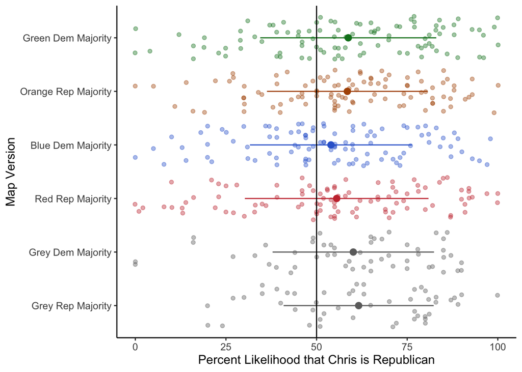

```r
plotTask2 <-ggplot(dt2long,aes(x=task2PercentRepublican,y=task2color,color=task2color,fill=task2color))+
    geom_point(position=position_jitter(width=.1,heigh=NULL),alpha=.4)+
  #geom_boxplot(alpha=.5)+
  stat_summary(fun = mean,
               fun.min = function(x) mean(x) - sd(x),
               fun.max = function(x) mean(x) + sd(x),
               geom = "pointrange")+
  scale_color_manual(values=c("#6d6d6d","#6d6d6d","#C8363C","#3267D2","#AF5303","#077F21"))+
    scale_fill_manual(values=c("#6d6d6d","#6d6d6d","#C8363C","#3267D2","#AF5303","#077F21"))+
    xlab("Percent Likelihood that Chris is Republican")+ylab("Map Version")+
  scale_y_discrete(labels=c("Grey Rep Majority","Grey Dem Majority","Red Rep Majority","Blue Dem Majority","Orange Rep Majority","Green Dem Majority"))+
    theme(text=element_text(size=12),
        legend.position="none",panel.grid.major = element_blank(),
        panel.grid.minor = element_blank(),
        panel.background = element_blank(),
        axis.line = element_line(colour = "black"))+geom_vline(xintercept=50)


plotTask2
```

```r
ggsave("baserate_task_scatterplot.png",plotTask2, height=7)
```

# Task 2 analyses

First we need to create separate color and political majority variables.

We’ll create a “majorityCond” where Dem= -.5 and Rep = .5.

```r
dt2long$majorityCond <-varRecode(dt2long$task2Version,c("Q260_1","Q266_1","Q272_1","Q275_1","Q184_1","Q278_1"),c(-.5,.5,-.5,.5,.5,-.5))
dt2long$colorCond <-as.factor(dt2long$condition)
```

Descriptive statistics for each of the experimental conditions:

```r
dt2summary <-aggregate(dt2long$task2PercentRepublican,by=list(dt2long$majorityCond,dt2long$colorCond),FUN=mean)
dt2summary <-varRename(dt2summary, c("Group.1","Group.2","x"),c("Majority Condition","Color Condition","Mean Estimate (percent Republican)"))
dt2summarySD <-aggregate(dt2long$task2PercentRepublican,by=list(dt2long$majorityCond,dt2long$colorCond),FUN=sd)
dt2summarySD <-varRename(dt2summarySD, c("Group.1","Group.2","x"),c("Majority Condition","Color Condition","SD Estimate"))
dt2summary <-join(dt2summary,dt2summarySD,by=c("Majority Condition","Color Condition"))
DT::datatable(dt2summary,caption="Mean and SD of voting behavior estimates by condition, Task 2")
```

|  | Majority Condition | Color Condition | Mean Estimate (percent Republican) | SD Estimate |
| --- | --- | --- | --- | --- |
| 1 | -0.5 | greenorange | 58.7474747474747 | 24.2808160750893 |
| 2 | 0.5 | greenorange | 58.4851485148515 | 22.1610531615202 |
| 3 | -0.5 | grey | 60.1320754716981 | 22.2676358247786 |
| 4 | 0.5 | grey | 61.6122448979592 | 20.7000566892648 |
| 5 | -0.5 | redblue | 53.970297029703 | 22.3501478498665 |
| 6 | 0.5 | redblue | 55.5463917525773 | 25.3332047496285 |

In our central analysis for Task 2, we’ll use grey (no color) as the reference level for our colorCond factor. That way the main effect of majorityCond will be a manipulation/attention check that participants are noticing the numeric information presented on the map. We will conduct parallel analyses with the participants’ ratings of *how important it is that the target vote* as the outcome variable.

```r
dt2long$colorCond<-relevel(dt2long$colorCond,ref="grey")
modTask2 <-lm(task2PercentRepublican~colorCond*majorityCond,data=dt2long)
summary(modTask2)
```

Call: lm(formula = task2PercentRepublican ~ colorCond * majorityCond, data = dt2long)

Residuals: Min 1Q Median 3Q Max -60.132 -13.747 0.515 18.253 44.454

Coefficients: Estimate Std. Error t value Pr(>|t|)  
(Intercept) 60.87216 2.29420 26.533 <2e-16 ** colorCondgreenorange -2.25585 2.81848 -0.800 0.4239  
colorCondredblue -6.11382 2.82343 -2.165 0.0308  
majorityCond 1.48017 4.58840 0.323 0.7471  
colorCondgreenorange:majorityCond -1.74250 5.63696 -0.309 0.7574  
colorCondredblue:majorityCond 0.09593 5.64685 0.017 0.9865  
— Signif. codes: 0 ‘**’ 0.001 ’**’ 0.01 ’’ 0.05 ‘.’ 0.1 ’ ’ 1

Residual standard error: 23.15 on 494 degrees of freedom Multiple R-squared: 0.01148, Adjusted R-squared: 0.001477 F-statistic: 1.148 on 5 and 494 DF, p-value: 0.3342

```r
modelEffectSizes(modTask2)
```

lm(formula = task2PercentRepublican ~ colorCond * majorityCond, data = dt2long)

Coefficients SSR df pEta-sqr dR-sqr (Intercept) 377371.5860 1 0.5876 NA colorCond 2893.8484 2 0.0108 0.0108 majorityCond 55.7821 1 0.0002 0.0002 colorCond:majorityCond 97.9485 2 0.0004 0.0004

Sum of squared errors (SSE): 264802.6 Sum of squared total (SST): 267878.4

Descriptive statistics of influence DV for each of the experimental conditions:

```r
dt2summary <-aggregate(dt2long$influence,by=list(dt2long$majorityCond,dt2long$colorCond),FUN=mean)
dt2summary <-varRename(dt2summary, c("Group.1","Group.2","x"),c("Majority Condition","Color Condition","Mean Estimate (influence)"))
dt2summarySD <-aggregate(dt2long$influence,by=list(dt2long$majorityCond,dt2long$colorCond),FUN=sd)
dt2summarySD <-varRename(dt2summarySD, c("Group.1","Group.2","x"),c("Majority Condition","Color Condition","SD Estimate"))
dt2summary <-join(dt2summary,dt2summarySD,by=c("Majority Condition","Color Condition"))
DT::datatable(dt2summary,caption="Mean and SD of influence estimates by condition, Task 2")
```

|  | Majority Condition | Color Condition | Mean Estimate (influence) | SD Estimate |
| --- | --- | --- | --- | --- |
| 1 | -0.5 | grey | 63.5471698113208 | 23.8735177048801 |
| 2 | 0.5 | grey | 66.4489795918367 | 22.2860767675039 |
| 3 | -0.5 | greenorange | 65.4444444444444 | 21.9820066595396 |
| 4 | 0.5 | greenorange | 63.6237623762376 | 22.5755848141963 |
| 5 | -0.5 | redblue | 62.5049504950495 | 22.8274500382221 |
| 6 | 0.5 | redblue | 65.3298969072165 | 25.6070960418708 |

```r
cor.test(dt2long$task2PercentRepublican,dt2long$influence)
```

```
Pearson's product-moment correlation
```

data: dt2long$task2PercentRepublican and dt2long$influence t = 5.0899, df = 498, p-value = 5.087e-07 alternative hypothesis: true correlation is not equal to 0 95 percent confidence interval: 0.1373622 0.3041341 sample estimates: cor 0.2223742

```r
modTask2influence <-lm(influence~colorCond*majorityCond,data=dt2long)
summary(modTask2influence)
```

Call: lm(formula = influence ~ colorCond * majorityCond, data = dt2long)

Residuals: Min 1Q Median 3Q Max -66.45 -12.57 2.67 17.38 37.49

Coefficients: Estimate Std. Error t value Pr(>|t|)  
(Intercept) 64.99807 2.30308 28.222 <2e-16 *** colorCondgreenorange -0.46397 2.82939 -0.164 0.870  
colorCondredblue -1.08065 2.83435 -0.381 0.703  
majorityCond 2.90181 4.60616 0.630 0.529  
colorCondgreenorange:majorityCond -4.72249 5.65877 -0.835 0.404  
colorCondredblue:majorityCond -0.07686 5.66870 -0.014 0.989  
— Signif. codes: 0 ‘**’ 0.001 ’**’ 0.01 ’’ 0.05 ‘.’ 0.1 ’ ’ 1

Residual standard error: 23.24 on 494 degrees of freedom Multiple R-squared: 0.003208, Adjusted R-squared: -0.006881 F-statistic: 0.318 on 5 and 494 DF, p-value: 0.9022

```r
modelEffectSizes(modTask2influence)
```

lm(formula = influence ~ colorCond * majorityCond, data = dt2long)

Coefficients SSR df pEta-sqr dR-sqr (Intercept) 430261.7651 1 0.6172 NA colorCond 85.9952 2 0.0003 0.0003 majorityCond 214.3925 1 0.0008 0.0008 colorCond:majorityCond 654.6078 2 0.0024 0.0024

Sum of squared errors (SSE): 266856.1 Sum of squared total (SST): 267714.9